# Ford GoBike Exploration

## by Motunrayo Ilawole

## Investigation Overview

> The factors that affect Durations of Trips.

## Dataset Overview

> This dataset includes information about individual rides made in a Bike system in the San Francisco Bay area.

## (Visualization 1)

> How long does the average trip take (average duration of trips)?

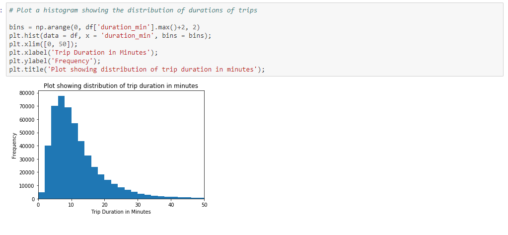

> As we can interpret from the plot from the previous slide, a greater number of people tend to use bikes for trips for a shorter period of time (around 10 minutes).

## (Visualization 2)

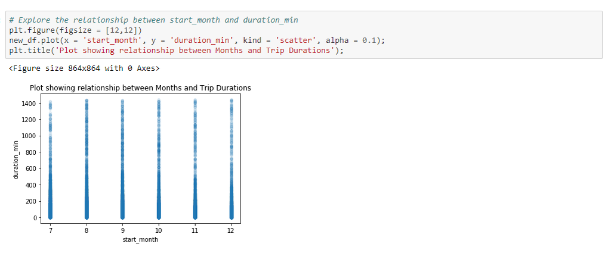

> There is no clear trend in the relationship between Trip duration and the months. There isn't much difference in the trip duration for each month. Therefore, we can conclude that individual months do not affect the trip duration

## (Visualization 3)

> Relationship between Trip Duration and User type

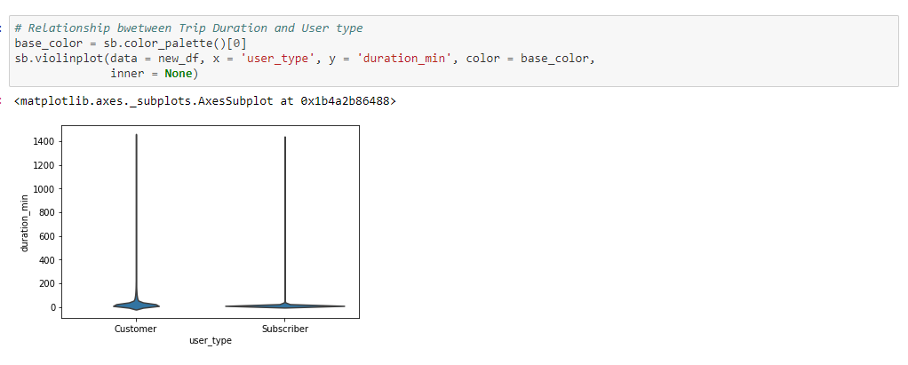

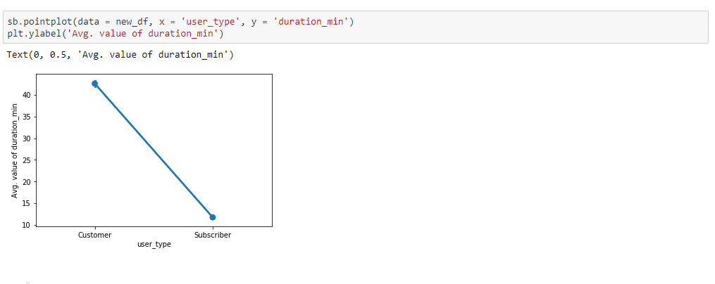

> From the plot in the previous slide, we can assume that customers take bikes on longer trips than subscribers.

## (Visualization 4)

> Whether the user being either a subscriber or customer affects how long the trip takes.

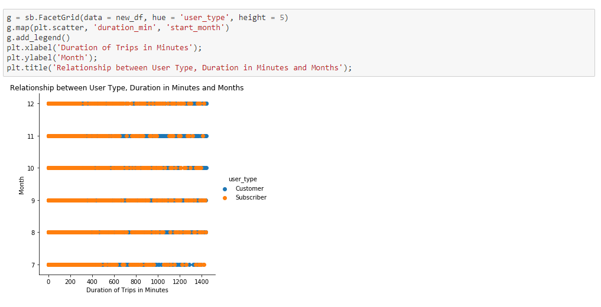

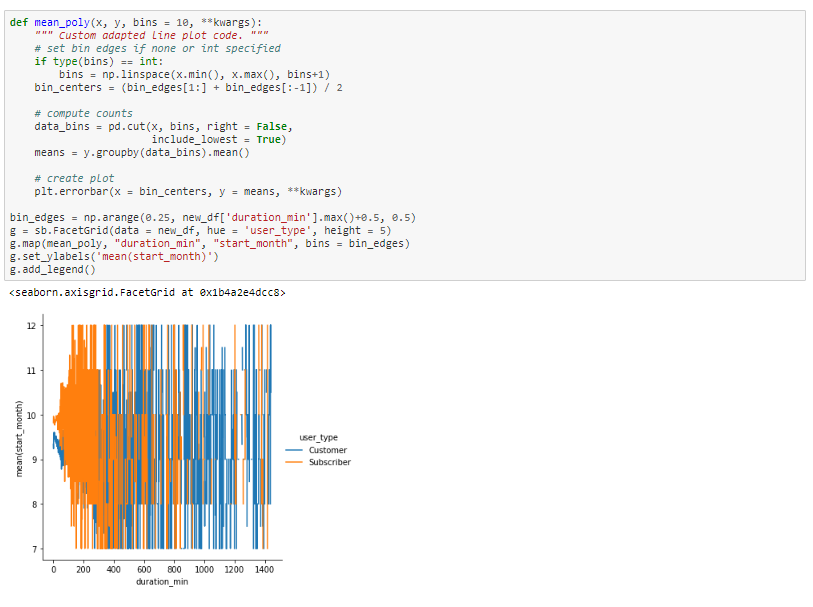

> Hence, we can conclude that user type does have an effect on duration of trips. It can also be seen here that customers, despite being smaller in number, tend to rent out bikes for longer trips.